# Work 7 - churn all ML models hyperparametering

```python
import sklearn
import joblib
import pandas as pd
import numpy as np
from joblib import dump
import matplotlib.pyplot as plt
from scipy import stats as st
import seaborn as sns
from sklearn.utils import shuffle
from sklearn.model_selection import train_test_split
from sklearn.ensemble import RandomForestRegressor
from sklearn.tree import DecisionTreeClassifier
from sklearn.ensemble import RandomForestClassifier
from sklearn.linear_model import LogisticRegression
from sklearn.linear_model import LinearRegression
from sklearn.metrics import accuracy_score, confusion_matrix, f1_score, recall_score
from sklearn.metrics import mean_squared_error, r2_score, mean_absolute_error, precision_score
from sklearn.metrics import roc_auc_score, precision_recall_curve, roc_curve
from sklearn.preprocessing import OrdinalEncoder, StandardScaler
```

```python
df = pd.read_csv('/datasets/Churn.csv')
display(df.head())
df.info()
df.describe()
```

|  | RowNumber | CustomerId | Surname | CreditScore | Geography | Gender | Age | Tenure | Balance | NumOfProducts | HasCrCard | IsActiveMember | EstimatedSalary | Exited |
| --- | --- | --- | --- | --- | --- | --- | --- | --- | --- | --- | --- | --- | --- | --- |
| 0 | 1 | 15634602 | Hargrave | 619 | France | Female | 42 | 2.0 | 0.00 | 1 | 1 | 1 | 101348.88 | 1 |
| 1 | 2 | 15647311 | Hill | 608 | Spain | Female | 41 | 1.0 | 83807.86 | 1 | 0 | 1 | 112542.58 | 0 |
| 2 | 3 | 15619304 | Onio | 502 | France | Female | 42 | 8.0 | 159660.80 | 3 | 1 | 0 | 113931.57 | 1 |
| 3 | 4 | 15701354 | Boni | 699 | France | Female | 39 | 1.0 | 0.00 | 2 | 0 | 0 | 93826.63 | 0 |
| 4 | 5 | 15737888 | Mitchell | 850 | Spain | Female | 43 | 2.0 | 125510.82 | 1 | 1 | 1 | 79084.10 | 0 |

```
<class 'pandas.core.frame.DataFrame'>
RangeIndex: 10000 entries, 0 to 9999
Data columns (total 14 columns):
RowNumber          10000 non-null int64
CustomerId         10000 non-null int64
Surname            10000 non-null object
CreditScore        10000 non-null int64
Geography          10000 non-null object
Gender             10000 non-null object
Age                10000 non-null int64
Tenure             9091 non-null float64
Balance            10000 non-null float64
NumOfProducts      10000 non-null int64
HasCrCard          10000 non-null int64
IsActiveMember     10000 non-null int64
EstimatedSalary    10000 non-null float64
Exited             10000 non-null int64
dtypes: float64(3), int64(8), object(3)
memory usage: 1.1+ MB
```

|  | RowNumber | CustomerId | CreditScore | Age | Tenure | Balance | NumOfProducts | HasCrCard | IsActiveMember | EstimatedSalary | Exited |
| --- | --- | --- | --- | --- | --- | --- | --- | --- | --- | --- | --- |
| count | 10000.00000 | 1.000000e+04 | 10000.000000 | 10000.000000 | 9091.000000 | 10000.000000 | 10000.000000 | 10000.00000 | 10000.000000 | 10000.000000 | 10000.000000 |
| mean | 5000.50000 | 1.569094e+07 | 650.528800 | 38.921800 | 4.997690 | 76485.889288 | 1.530200 | 0.70550 | 0.515100 | 100090.239881 | 0.203700 |
| std | 2886.89568 | 7.193619e+04 | 96.653299 | 10.487806 | 2.894723 | 62397.405202 | 0.581654 | 0.45584 | 0.499797 | 57510.492818 | 0.402769 |
| min | 1.00000 | 1.556570e+07 | 350.000000 | 18.000000 | 0.000000 | 0.000000 | 1.000000 | 0.00000 | 0.000000 | 11.580000 | 0.000000 |
| 25% | 2500.75000 | 1.562853e+07 | 584.000000 | 32.000000 | 2.000000 | 0.000000 | 1.000000 | 0.00000 | 0.000000 | 51002.110000 | 0.000000 |
| 50% | 5000.50000 | 1.569074e+07 | 652.000000 | 37.000000 | 5.000000 | 97198.540000 | 1.000000 | 1.00000 | 1.000000 | 100193.915000 | 0.000000 |
| 75% | 7500.25000 | 1.575323e+07 | 718.000000 | 44.000000 | 7.000000 | 127644.240000 | 2.000000 | 1.00000 | 1.000000 | 149388.247500 | 0.000000 |
| max | 10000.00000 | 1.581569e+07 | 850.000000 | 92.000000 | 10.000000 | 250898.090000 | 4.000000 | 1.00000 | 1.000000 | 199992.480000 | 1.000000 |

# Preparing the data

We already can see that the amount of Exited=1 is much less that Exited=0 (by the 75%). We will need to refactor the table. 'Tenure" is the only column with nulls. Both median and mean are 5.0. Row number and ID are not necessary to the model.

```python
df['Tenure'] = df['Tenure'].fillna(5.0)
df = df.drop(columns=['RowNumber', 'CustomerId'])
df.info()
```

```
<class 'pandas.core.frame.DataFrame'>
RangeIndex: 10000 entries, 0 to 9999
Data columns (total 12 columns):
Surname            10000 non-null object
CreditScore        10000 non-null int64
Geography          10000 non-null object
Gender             10000 non-null object
Age                10000 non-null int64
Tenure             10000 non-null float64
Balance            10000 non-null float64
NumOfProducts      10000 non-null int64
HasCrCard          10000 non-null int64
IsActiveMember     10000 non-null int64
EstimatedSalary    10000 non-null float64
Exited             10000 non-null int64
dtypes: float64(3), int64(6), object(3)
memory usage: 937.6+ KB
```

```python
print(len(df['Surname'].unique()))
df = df.drop(columns=['Surname'])
print(df['Geography'].unique())
print(df['Gender'].unique())
print(df['Exited'].value_counts())
```

```
2932
['France' 'Spain' 'Germany']
['Female' 'Male']
0    7963
1    2037
Name: Exited, dtype: int64
```

```python
data_ohe = pd.get_dummies(df, drop_first=True)
```

Surname has too many unique values, 'Geography' and 'Gender' will be categorized by numbers if needed.

# Balance of classes

We will need to upsample observations where 'Exited' = 1.

```python
target = data_ohe['Exited']
features = data_ohe.drop('Exited', axis=1)
features_1, features_test, target_1, target_test = train_test_split(
    features, target, test_size=0.25, random_state=12345)
features_train, features_valid, target_train, target_valid = train_test_split(
    features_1, target_1, test_size=0.25, random_state=12345)
```

```python
def print_score(target_valid,predicted_valid):
    print("F1:", f1_score(target_valid, predicted_valid))
    print("Recall:",recall_score(target_valid,predicted_valid))
    print("Precision:",precision_score(target_valid,predicted_valid))
    print("Confusion Matrix:",confusion_matrix(target_valid,predicted_valid))
```

Recall is the share of TP among all answers that have a true label of 1. We want the recall value to be close to 1. This would mean that the model is good at identifying true positives. If it is closer to zero, the model needs to be checked and fixed.

Precision measures how many negative answers the model found while searching for positive ones. The more negative answers are found, the lower the precision.

F1 score is the harmonic mean of recall and precision, and helps to control them simultaneously.

AUC-ROC value finds how much our model differs from the random model (Area Under Curve ROC). This evaluation metric with values in the range from 0 to 1. The AUC-ROC value for a random model is 0.5.

## LogisticRegression

```python
model1 = LogisticRegression(random_state=12345, max_iter=100, solver='liblinear')
model1.fit(features_train, target_train)
predicted_valid = model1.predict(features_valid)

print_score(target_valid,predicted_valid)
```

```
F1: 0.09389671361502347
Recall: 0.05263157894736842
Precision: 0.43478260869565216
Confusion Matrix: [[1469   26]
 [ 360   20]]
```

Recall is very low, thus, the model fails to identify true positives. Precision is much better, but still under 0.5, meaning that the model found more negative answers while searching for positive ones. F1 value is very low, this model is not good.

## DecisionTreeClassifier

```python
model2 = DecisionTreeClassifier(random_state=12345,max_depth=3)
model2.fit(features_train, target_train)
predicted_valid = model2.predict(features_valid)

print_score(target_valid,predicted_valid)
```

```
F1: 0.42578125
Recall: 0.2868421052631579
Precision: 0.8257575757575758
Confusion Matrix: [[1472   23]
 [ 271  109]]
```

Recall is lower than the precision, and lower than 0.5. The model fails to identify true positives, probably because it is not balance. Precision is much better, and over 0.5, meaning that the model found more positive answers while searching for positive ones. F1 value is better but still lower than what we were looking for. The harmonic between Recall and Precision is still far.

## RandomForestClassifier

```python
model3 = RandomForestClassifier(random_state=12345,n_estimators=3)
model3.fit(features_train, target_train)
predicted_valid = model3.predict(features_valid)

print_score(target_valid,predicted_valid)
```

```
F1: 0.5
Recall: 0.45263157894736844
Precision: 0.5584415584415584
Confusion Matrix: [[1359  136]
 [ 208  172]]
```

Recall is lower than the precision, and lower than 0.5. Although the model fails to identify true positives, it has the best Recall value. Precision is better, and over 0.5, meaning that the model found more positive answers while searching for positive ones. It is still lower than the last model, but not bad. F1 value is again better and closer to what we were looking for. The harmonic between Recall and Precision is improving.

```
AUC-ROC: 0.6972997711670481
```

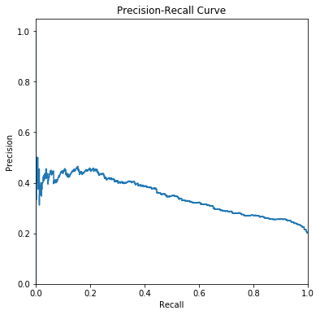

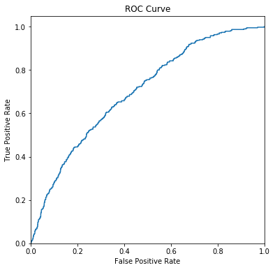

```python
probabilities_valid = model1.predict_proba(features_valid)
auc_roc = roc_auc_score(target_valid, probabilities_valid[:, 1])
print("AUC-ROC:",auc_roc)
precision, recall, thresholds = precision_recall_curve(target_valid, probabilities_valid[:, 1])

plt.figure(figsize=(6, 6))
plt.step(recall, precision, where='post')
plt.xlabel('Recall')
plt.ylabel('Precision')
plt.ylim([0.0, 1.05])
plt.xlim([0.0, 1.0])
plt.title('Precision-Recall Curve')
plt.show()

fpr, tpr, thresholds = roc_curve(target_valid, probabilities_valid[:, 1])
plt.figure(figsize=(6, 6))
plt.step(fpr, tpr, where='post')
plt.xlabel('False Positive Rate')
plt.ylabel('True Positive Rate')
plt.ylim([0.0, 1.05])
plt.xlim([0.0, 1.0])
plt.title('ROC Curve')
plt.show()
```

```
AUC-ROC: 0.8054409434958633
```

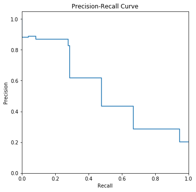

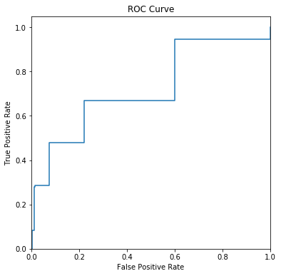

```python
probabilities_valid = model2.predict_proba(features_valid)
auc_roc = roc_auc_score(target_valid, probabilities_valid[:, 1])
print("AUC-ROC:",auc_roc)
precision, recall, thresholds = precision_recall_curve(target_valid, probabilities_valid[:, 1])

plt.figure(figsize=(6, 6))
plt.step(recall, precision, where='post')
plt.xlabel('Recall')
plt.ylabel('Precision')
plt.ylim([0.0, 1.05])
plt.xlim([0.0, 1.0])
plt.title('Precision-Recall Curve')
plt.show()

fpr, tpr, thresholds = roc_curve(target_valid, probabilities_valid[:, 1])
plt.figure(figsize=(6, 6))
plt.step(fpr, tpr, where='post')
plt.xlabel('False Positive Rate')
plt.ylabel('True Positive Rate')
plt.ylim([0.0, 1.05])
plt.xlim([0.0, 1.0])
plt.title('ROC Curve')
plt.show()
```

```
AUC-ROC: 0.761578947368421
```

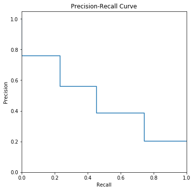

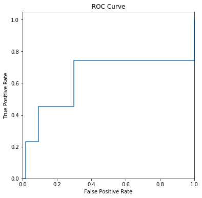

```python
probabilities_valid = model3.predict_proba(features_valid)
auc_roc = roc_auc_score(target_valid, probabilities_valid[:, 1])
print("AUC-ROC:",auc_roc)
precision, recall, thresholds = precision_recall_curve(target_valid, probabilities_valid[:, 1])

plt.figure(figsize=(6, 6))
plt.step(recall, precision, where='post')
plt.xlabel('Recall')
plt.ylabel('Precision')
plt.ylim([0.0, 1.05])
plt.xlim([0.0, 1.0])
plt.title('Precision-Recall Curve')
plt.show()

fpr, tpr, thresholds = roc_curve(target_valid, probabilities_valid[:, 1])
plt.figure(figsize=(6, 6))
plt.step(fpr, tpr, where='post')
plt.xlabel('False Positive Rate')
plt.ylabel('True Positive Rate')
plt.ylim([0.0, 1.05])
plt.xlim([0.0, 1.0])
plt.title('ROC Curve')
plt.show()
```

## Conclusion

Our first model is far from the excpected 0.59 value for F1. The best model by now is the RandomForestClassifier. All models had lower Recall, meaning the target value is not balanced. The last two models does not seemed random.

# Improving the quality of the model

The target =1 is almost 4 times smaller than target=0. Thus, we will multiplicate it by 4. I will check for the best hyperparameters for each model.

## Upsampling

```python
def upsample(features, target, repeat):
    features_zeros = features[target == 0]
    features_ones = features[target == 1]
    target_zeros = target[target == 0]
    target_ones = target[target == 1]

    features_upsampled = pd.concat([features_zeros] + [features_ones] * repeat)
    target_upsampled = pd.concat([target_zeros] + [target_ones] * repeat)

    features_upsampled, target_upsampled = shuffle(
        features_upsampled, target_upsampled, random_state=12345)

    return features_upsampled, target_upsampled

features_upsampled, target_upsampled = upsample(features_train, target_train, 4)
print(features_upsampled.shape)
print(target_upsampled.shape)
```

```
(8991, 11)
(8991,)
```

```python
model4 = RandomForestClassifier(random_state=12345,n_estimators=3)
model4.fit(features_upsampled, target_upsampled)
predicted_valid = model4.predict(features_valid)

print_score(target_valid,predicted_valid)
```

```
F1: 0.49801324503311256
Recall: 0.49473684210526314
Precision: 0.5013333333333333
Confusion Matrix: [[1308  187]
 [ 192  188]]
```

```python
model5 = DecisionTreeClassifier(random_state=12345,max_depth=3)
model5.fit(features_upsampled, target_upsampled)
predicted_valid = model5.predict(features_valid)

print_score(target_valid,predicted_valid)
```

```
F1: 0.5171400587659157
Recall: 0.6947368421052632
Precision: 0.4118564742589704
Confusion Matrix: [[1118  377]
 [ 116  264]]
```

```python
model6 = LogisticRegression(random_state=12345, max_iter=100, solver='liblinear')
model6.fit(features_upsampled, target_upsampled)
predicted_valid = model6.predict(features_valid)

print_score(target_valid,predicted_valid)
```

```
F1: 0.45523012552301256
Recall: 0.7157894736842105
Precision: 0.3337423312883436
Confusion Matrix: [[952 543]
 [108 272]]
```

```python
#Scaling
numeric = ['CreditScore', 'Age', 'Tenure', 'NumOfProducts', 'EstimatedSalary']
features_upsampled_scaler = features_upsampled
scaler = StandardScaler()
scaler.fit(features_upsampled_scaler[numeric])
features_upsampled_scaler[numeric] = scaler.transform(features_upsampled_scaler[numeric])

features_valid[numeric] = scaler.transform(features_valid[numeric])
```

```python
for depth in range(1,10):
    dtc_model = DecisionTreeClassifier(max_depth=depth, random_state=12345)
    dtc_model.fit(features_upsampled_scaler, target_upsampled)
    dtc_predicted_valid = dtc_model.predict(features_valid)
    print("max_depth =", depth, ": ", end='')
    print(accuracy_score(target_valid, dtc_predicted_valid))
    print_score(target_valid,dtc_predicted_valid)
```

```
max_depth = 1 : 0.7317333333333333
F1: 0.4944723618090453
Recall: 0.6473684210526316
Precision: 0.4
Confusion Matrix: [[1126  369]
 [ 134  246]]
max_depth = 2 : 0.7370666666666666
F1: 0.5171400587659157
Recall: 0.6947368421052632
Precision: 0.4118564742589704
Confusion Matrix: [[1118  377]
 [ 116  264]]
max_depth = 3 : 0.7370666666666666
F1: 0.5171400587659157
Recall: 0.6947368421052632
Precision: 0.4118564742589704
Confusion Matrix: [[1118  377]
 [ 116  264]]
max_depth = 4 : 0.7509333333333333
F1: 0.5479186834462729
Recall: 0.7447368421052631
Precision: 0.4333843797856049
Confusion Matrix: [[1125  370]
 [  97  283]]
max_depth = 5 : 0.7338666666666667
F1: 0.5556544968833482
Recall: 0.8210526315789474
Precision: 0.4199192462987887
Confusion Matrix: [[1064  431]
 [  68  312]]
max_depth = 6 : 0.7690666666666667
F1: 0.5759059745347698
Recall: 0.7736842105263158
Precision: 0.45865834633385333
Confusion Matrix: [[1148  347]
 [  86  294]]
max_depth = 7 : 0.7573333333333333
F1: 0.5687203791469194
Recall: 0.7894736842105263
Precision: 0.4444444444444444
Confusion Matrix: [[1120  375]
 [  80  300]]
max_depth = 8 : 0.7861333333333334
F1: 0.570203644158628
Recall: 0.7
Precision: 0.4810126582278481
Confusion Matrix: [[1208  287]
 [ 114  266]]
max_depth = 9 : 0.7584
F1: 0.5492537313432836
Recall: 0.7263157894736842
Precision: 0.4416
Confusion Matrix: [[1146  349]
 [ 104  276]]
```

```python
for estimators in range(1,15):
    rfc_model = RandomForestClassifier(n_estimators=estimators, random_state=12345)
    rfc_model.fit(features_upsampled_scaler, target_upsampled)
    rfc_predicted_valid = rfc_model.predict(features_valid)
    print("estimators =", estimators, ": ", end='')
    print(accuracy_score(target_valid, rfc_predicted_valid))
    print_score(target_valid,rfc_predicted_valid)
```

```
estimators = 1 : 0.7536
F1: 0.471395881006865
Recall: 0.5421052631578948
Precision: 0.41700404858299595
Confusion Matrix: [[1207  288]
 [ 174  206]]
estimators = 2 : 0.824
F1: 0.4481605351170569
Recall: 0.3526315789473684
Precision: 0.6146788990825688
Confusion Matrix: [[1411   84]
 [ 246  134]]
estimators = 3 : 0.7973333333333333
F1: 0.4973544973544973
Recall: 0.49473684210526314
Precision: 0.5
Confusion Matrix: [[1307  188]
 [ 192  188]]
estimators = 4 : 0.8282666666666667
F1: 0.4772727272727273
Recall: 0.3868421052631579
Precision: 0.6228813559322034
Confusion Matrix: [[1406   89]
 [ 233  147]]
estimators = 5 : 0.8090666666666667
F1: 0.5068870523415978
Recall: 0.4842105263157895
Precision: 0.5317919075144508
Confusion Matrix: [[1333  162]
 [ 196  184]]
estimators = 6 : 0.8288
F1: 0.5053929121725732
Recall: 0.43157894736842106
Precision: 0.6096654275092936
Confusion Matrix: [[1390  105]
 [ 216  164]]
estimators = 7 : 0.8213333333333334
F1: 0.5314685314685315
Recall: 0.5
Precision: 0.5671641791044776
```

[output cut: 29 more lines]

```
Precision: 0.6428571428571429
Confusion Matrix: [[1395  100]
 [ 200  180]]
estimators = 13 : 0.8352
F1: 0.5553956834532374
Recall: 0.5078947368421053
Precision: 0.6126984126984127
Confusion Matrix: [[1373  122]
 [ 187  193]]
estimators = 14 : 0.8389333333333333
F1: 0.5492537313432835
Recall: 0.4842105263157895
Precision: 0.6344827586206897
Confusion Matrix: [[1389  106]
 [ 196  184]]
```

```python
for iterations in range(50,151,25):
    lrc_model = LogisticRegression(max_iter=iterations, random_state=12345)
    lrc_model.fit(features_upsampled_scaler, target_upsampled)
    lrc_predicted_valid = lrc_model.predict(features_valid)
    print("iterations =", iterations, ": ", end='')
    print(accuracy_score(target_valid, lrc_predicted_valid))
    print_score(target_valid,lrc_predicted_valid)
```

```
iterations = 50 : 0.4554666666666667
F1: 0.4004697592483852
Recall: 0.8973684210526316
Precision: 0.25774754346182915
Confusion Matrix: [[513 982]
 [ 39 341]]
```

```
iterations = 75 : 0.4554666666666667
F1: 0.4004697592483852
Recall: 0.8973684210526316
Precision: 0.25774754346182915
Confusion Matrix: [[513 982]
 [ 39 341]]
iterations = 100 : 0.4554666666666667
F1: 0.4004697592483852
Recall: 0.8973684210526316
```

```
Precision: 0.25774754346182915
Confusion Matrix: [[513 982]
 [ 39 341]]
iterations = 125 : 0.4554666666666667
F1: 0.4004697592483852
Recall: 0.8973684210526316
Precision: 0.25774754346182915
Confusion Matrix: [[513 982]
 [ 39 341]]
iterations = 150 : 0.4554666666666667
F1: 0.4004697592483852
Recall: 0.8973684210526316
Precision: 0.25774754346182915
Confusion Matrix: [[513 982]
 [ 39 341]]
```

For DecisionTreeClassifier the best result was for depth = 6, F1 = 0.57590.

For LogisticRegression the best result was for iterations = 50, F1 = 0.40046.

## Downsampling

```python
def downsample(features, target, fraction):
    features_zeros = features[target == 0]
    features_ones = features[target == 1]
    target_zeros = target[target == 0]
    target_ones = target[target == 1]

    features_downsampled = pd.concat(
        [features_zeros.sample(frac=fraction, random_state=12345)] + [features_ones])
    target_downsampled = pd.concat(
        [target_zeros.sample(frac=fraction, random_state=12345)] + [target_ones])

    features_downsampled, target_downsampled = shuffle(
        features_downsampled, target_downsampled, random_state=12345)

    return features_downsampled, target_downsampled

features_downsampled, target_downsampled = downsample(features_train, target_train, 0.25)
print(features_downsampled.shape)
print(target_downsampled.shape)
```

```
(2248, 11)
(2248,)
```

```python
#Scaling
numeric = ['CreditScore', 'Age', 'Tenure', 'NumOfProducts', 'EstimatedSalary']
features_downsampled_scaler = features_downsampled
scaler = StandardScaler()
scaler.fit(features_downsampled_scaler[numeric])
features_downsampled_scaler[numeric] = scaler.transform(features_downsampled_scaler[numeric])

features_valid[numeric] = scaler.transform(features_valid[numeric])
```

```python
for depth in range(1,10):
    dtc_model = DecisionTreeClassifier(max_depth=depth, random_state=12345)
    dtc_model.fit(features_downsampled_scaler, target_downsampled)
    dtc_predicted_valid = dtc_model.predict(features_valid)
    print("max_depth =", depth, ": ", end='')
    print(accuracy_score(target_valid, dtc_predicted_valid))
    print_score(target_valid,dtc_predicted_valid)
```

```
max_depth = 1 : 0.7973333333333333
F1: 0.0
Recall: 0.0
Precision: 0.0
Confusion Matrix: [[1495    0]
 [ 380    0]]
max_depth = 2 : 0.8021333333333334
F1: 0.04627249357326479
Recall: 0.02368421052631579
Precision: 1.0
Confusion Matrix: [[1495    0]
 [ 371    9]]
max_depth = 3 : 0.8021333333333334
F1: 0.04627249357326479
Recall: 0.02368421052631579
Precision: 1.0
Confusion Matrix: [[1495    0]
 [ 371    9]]
max_depth = 4 : 0.7130666666666666
F1: 0.3502415458937198
Recall: 0.3815789473684211
Precision: 0.3236607142857143
Confusion Matrix: [[1192  303]
 [ 235  145]]
max_depth = 5 : 0.4629333333333333
F1: 0.29034531360112753
Recall: 0.5421052631578948
Precision: 0.19826756496631376
Confusion Matrix: [[662 833]
 [174 206]]
max_depth = 6 : 0.6554666666666666
F1: 0.3421588594704684
Recall: 0.4421052631578947
Precision: 0.27906976744186046
Confusion Matrix: [[1061  434]
 [ 212  168]]
max_depth = 7 : 0.5376
F1: 0.3058446757405925
Recall: 0.5026315789473684
Precision: 0.21979286536248563
Confusion Matrix: [[817 678]
 [189 191]]
max_depth = 8 : 0.44266666666666665
F1: 0.29912810194500333
Recall: 0.5868421052631579
Precision: 0.2007200720072007
Confusion Matrix: [[607 888]
 [157 223]]
max_depth = 9 : 0.456
F1: 0.32982917214191854
Recall: 0.6605263157894737
Precision: 0.21978984238178634
Confusion Matrix: [[604 891]
 [129 251]]
```

```python
for estimators in range(1,15):
    rfc_model = RandomForestClassifier(n_estimators=estimators, random_state=12345)
    rfc_model.fit(features_downsampled_scaler, target_downsampled)
    rfc_predicted_valid = rfc_model.predict(features_valid)
    print("estimators =", estimators, ": ", end='')
    print(accuracy_score(target_valid, rfc_predicted_valid))
    print_score(target_valid,rfc_predicted_valid)
```

```
estimators = 1 : 0.2554666666666667
F1: 0.2605932203389831
Recall: 0.6473684210526316
Precision: 0.16312997347480107
Confusion Matrix: [[ 233 1262]
 [ 134  246]]
estimators = 2 : 0.32693333333333335
F1: 0.23236009732360097
Recall: 0.5026315789473684
Precision: 0.15110759493670886
Confusion Matrix: [[ 422 1073]
 [ 189  191]]
estimators = 3 : 0.25493333333333335
F1: 0.29050279329608936
Recall: 0.7526315789473684
Precision: 0.17998741346758967
Confusion Matrix: [[ 192 1303]
 [  94  286]]
estimators = 4 : 0.47733333333333333
F1: 0.19407894736842105
Recall: 0.3105263157894737
Precision: 0.14114832535885166
Confusion Matrix: [[777 718]
 [262 118]]
estimators = 5 : 0.34986666666666666
F1: 0.2850439882697947
Recall: 0.6394736842105263
Precision: 0.18339622641509434
Confusion Matrix: [[ 413 1082]
 [ 137  243]]
estimators = 6 : 0.4192
F1: 0.26369168356997974
Recall: 0.5131578947368421
Precision: 0.17743403093721566
Confusion Matrix: [[591 904]
 [185 195]]
estimators = 7 : 0.2832
F1: 0.2978056426332288
Recall: 0.75
Precision: 0.18578878748370273
```

[output cut: 29 more lines]

```
Precision: 0.18616144975288304
Confusion Matrix: [[507 988]
 [154 226]]
estimators = 13 : 0.32053333333333334
F1: 0.30076838638858394
Recall: 0.7210526315789474
Precision: 0.1900138696255201
Confusion Matrix: [[ 327 1168]
 [ 106  274]]
estimators = 14 : 0.4245333333333333
F1: 0.26748133061778684
Recall: 0.5184210526315789
Precision: 0.18023787740164685
Confusion Matrix: [[599 896]
 [183 197]]
```

```python
for iterations in range(50,151,25):
    lrc_model = LogisticRegression(max_iter=iterations, random_state=12345, solver='liblinear')
    lrc_model.fit(features_downsampled_scaler, target_downsampled)
    lrc_predicted_valid = lrc_model.predict(features_valid)
    print("iterations =", iterations, ": ", end='')
    print(accuracy_score(target_valid, lrc_predicted_valid))
    print_score(target_valid,lrc_predicted_valid)
```

```
iterations = 50 : 0.46026666666666666
F1: 0.36432160804020103
Recall: 0.7631578947368421
Precision: 0.23927392739273928
Confusion Matrix: [[573 922]
 [ 90 290]]
iterations = 75 : 0.46026666666666666
F1: 0.36432160804020103
Recall: 0.7631578947368421
Precision: 0.23927392739273928
Confusion Matrix: [[573 922]
 [ 90 290]]
iterations = 100 : 0.46026666666666666
F1: 0.36432160804020103
Recall: 0.7631578947368421
Precision: 0.23927392739273928
Confusion Matrix: [[573 922]
 [ 90 290]]
iterations = 125 : 0.46026666666666666
F1: 0.36432160804020103
Recall: 0.7631578947368421
Precision: 0.23927392739273928
Confusion Matrix: [[573 922]
 [ 90 290]]
iterations = 150 : 0.46026666666666666
F1: 0.36432160804020103
Recall: 0.7631578947368421
Precision: 0.23927392739273928
Confusion Matrix: [[573 922]
 [ 90 290]]
```

For LogisticRegression the best result was for iterations = 50, F1 = 0.3643.

For RandomForestClassifier the best result was for estimators = 13, F1 = 0.30076.

Recall improved, but Precision got much worst. Ofcourse, this is since we have less observations to study from, and the percent of the True observation grew against the others.

## Balancing

For Logistic Regression

```python
for iterations in range(50,151,25):
    lrc_model = LogisticRegression(max_iter=iterations, random_state=12345, class_weight='balanced', solver='liblinear')
    lrc_model.fit(features_train, target_train)
    lrc_predicted_valid = lrc_model.predict(features_valid)
    print("iterations =", iterations, ": ", end='')
    print(accuracy_score(target_valid, lrc_predicted_valid))
    print_score(target_valid,lrc_predicted_valid)
```

```
iterations = 50 : 0.7642666666666666
F1: 0.3499999999999999
Recall: 0.3131578947368421
Precision: 0.39666666666666667
Confusion Matrix: [[1314  181]
 [ 261  119]]
iterations = 75 : 0.7642666666666666
F1: 0.3499999999999999
Recall: 0.3131578947368421
Precision: 0.39666666666666667
Confusion Matrix: [[1314  181]
 [ 261  119]]
iterations = 100 : 0.7642666666666666
F1: 0.3499999999999999
Recall: 0.3131578947368421
Precision: 0.39666666666666667
Confusion Matrix: [[1314  181]
 [ 261  119]]
iterations = 125 : 0.7642666666666666
F1: 0.3499999999999999
Recall: 0.3131578947368421
Precision: 0.39666666666666667
Confusion Matrix: [[1314  181]
 [ 261  119]]
iterations = 150 : 0.7642666666666666
F1: 0.3499999999999999
Recall: 0.3131578947368421
Precision: 0.39666666666666667
Confusion Matrix: [[1314  181]
 [ 261  119]]
```

Balancing did not get a good result neither, of F1 value = 0.34999.

# Final Testing

I will up-sample all the train (train + validation) data, then scale the data. train is 75%, test 25%.

```python
features_upsampled_for_test, target_upsampled_for_test = upsample(features_1, target_1, 4)
print(features_upsampled_for_test.shape)
print(target_upsampled_for_test.shape)
```

```
(12006, 11)
(12006,)
```

```python
#Scaling
numeric = ['CreditScore', 'Age', 'Tenure', 'NumOfProducts', 'EstimatedSalary']
features_upsampled_scaler_for_test = features_upsampled_for_test
scaler = StandardScaler()
scaler.fit(features_upsampled_scaler_for_test[numeric])
features_upsampled_scaler_for_test[numeric] = scaler.transform(features_upsampled_scaler_for_test[numeric])

features_test[numeric] = scaler.transform(features_test[numeric])
```

```python
#The model
model7 = RandomForestClassifier(n_estimators=11, random_state=12345)
model7.fit(features_upsampled_scaler_for_test, target_upsampled_for_test)
predicted_test = model7.predict(features_test)

print_score(target_test,predicted_test)
```

```
F1: 0.6129353233830845
Recall: 0.5757009345794393
Precision: 0.6553191489361702
Confusion Matrix: [[1803  162]
 [ 227  308]]
```

```
AUC-ROC: 0.8304045088107299
```

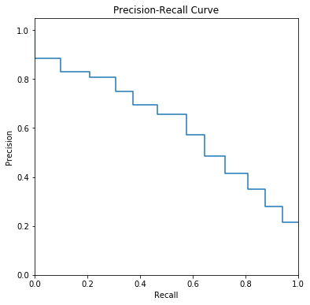

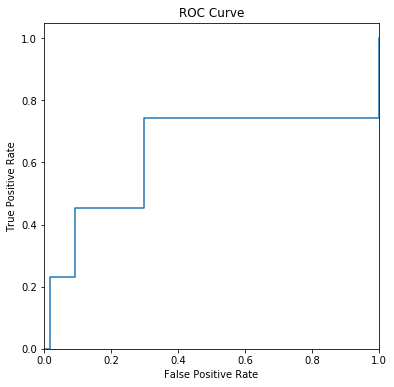

```python
probabilities_test = model7.predict_proba(features_test)
auc_roc = roc_auc_score(target_test, probabilities_test[:, 1])
print("AUC-ROC:",auc_roc)
precision, recall, thresholds = precision_recall_curve(target_test, probabilities_test[:, 1])

plt.figure(figsize=(6, 6))
plt.step(recall, precision, where='post')
plt.xlabel('Recall')
plt.ylabel('Precision')
plt.ylim([0.0, 1.05])
plt.xlim([0.0, 1.0])
plt.title('Precision-Recall Curve')
plt.show()

fpr, tpr, thresholds = roc_curve(target_valid, probabilities_valid[:, 1])
plt.figure(figsize=(6, 6))
plt.step(fpr, tpr, where='post')
plt.xlabel('False Positive Rate')
plt.ylabel('True Positive Rate')
plt.ylim([0.0, 1.05])
plt.xlim([0.0, 1.0])
plt.title('ROC Curve')
plt.show()
```

# Conclusion

Our model oachieved a F1 score of 0.612935. Recall and Precision are very armonic. AUC-ROC value is 0.830404, is very high, showing that our performance is not random.